# BMI Documentation

Fábio Corrêa Didoné

Friday, March 13, 2015

# Body Mass Index(BMI) calculator

## BMI

The BMI is a number calculated from a person’s wieght and height. It is a reliable indicator of body fatness for most people. However, BMI does not measure body fat directly, but reseacrh has shown that it correlates to direct measures of body fat. BMI is used as a screening tool to identify possible weight problems for adults. However, it is not a diagnotic tool.to determine if excess weight is a health risk, a *healthcare provider would need to perform further assessments.*

## calculation

The formula to calculate the BMI is the weight divided by the height squared.The results are given in kg/mÂ². The bmi works well for all ages, genders and races. However, special attention must be given for childs and asians.This table show how to basic interpret the results of BMI:

Source: http://www.cdc.gov/healthyweight/assessing/bmi/adult_bmi/

```r
library(knitr)
kable(data.frame(Status = c("Underweight","Normal","Overweight","Obese"),
           "BMI"=c("< 18.5","18.5-25","25-30","> 30")))
```

| Status | BMI |
| --- | --- |
| Underweight | < 18.5 |
| Normal | 18.5-25 |
| Overweight | 25-30 |
| Obese | > 30 |

## The app

The app can calculate the BMI with two set of unit: Metric - **centimeters and kilograms** or Imperial: - **feet and pounds**. The basic calculation performed by the app is descibred in the formula below,

```r
BMI <- function(weight,height,units)  {
        if(units == "metric") {
                round(weight/(height/100)^2,2)->temp1
                temp1
        }
        else if(units == "imperial"){
                round((weight/(height*12)^2)*703,2)-> temp1
                temp1
        }
}
```

## Plot

The app also plots a graph of where are your BMI in the scale of the BMI. The code fot the graph for a BMI of 22 and height of 170 cm:

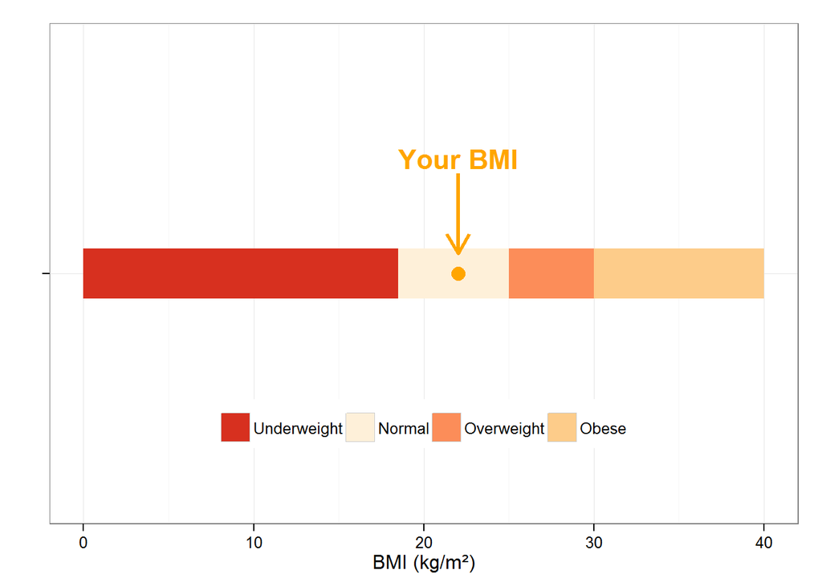

```r
library(ggplot2); library(grid)

data.frame(Status = c("Underweight","Normal","Overweight","Obese"),
           BMI=c(18.5,6.5,5,10),id=rep("",4) )-> gr




ggplot(data=gr,aes(x=id,y=BMI,fill=Status,width=0.1))+
                        geom_bar(stat="identity",position="stack",size=1)+
        coord_flip()+
                        scale_fill_brewer(type="div",palette="OrRd",breaks=c("Underweight","Normal","Overweight","Obese"))+
                        scale_x_discrete(name="")+theme_bw()+theme(legend.position="top")+theme(legend.position=c(0.5,0.2))+
                        guides(fill=guide_legend(title=NULL,nrow=1))+
                        annotate("segment",y=22,x=1.2,yend=22,xend=1.04,col="orange",size=1.2, arrow  =arrow(length= unit(0.5,"cm")))+
                        annotate("text", label= "Your BMI",x=1.23,y=22,col="orange",size=6,fontface="bold")+annotate("point",x=1,y=22,size=4,col="orange")+
        scale_y_continuous(name = enc2native("BMI (kg/m²)"))
```

## Table

The app produces a table showing the relationship between the BMI and you current height.

This a table for a person with 5.6 feet:

| Status | BMI. | Weight |
| --- | --- | --- |
| Underweight | < 18.5 kg/m^2 | < 118.8 lb |
| Normal | 18.5 kg/m^2 - 25 kg/m^2 | 118.8 lb - 160.6 lb |
| Overweight | 25 kg/m^2 - 30 kg/m^2 | 160.6 lb - 192.7 lb |
| Obese | > 30 kg/m^2 | > 192.7 lb |

## Conclusion

The app does what is asked to do, despite being simple and with not big computation or prediction. This is a course project for the Coursera course developing data products. Hope you guys enjoy it!